# examples_0305

Consider the following product of linear binomials:

$$({8}x+{9})({-9}x+{1})$$

When the expression is expanded and like terms are combined, an equivalent expression can be expressed in standard form:

$$ax^2+bx+c$$

where $a$, $b$, and $c$ are integers.

- What is the value of $b$?

You could use the box method.

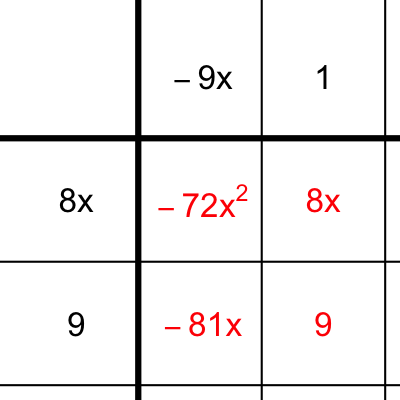

Or, you can FOIL...

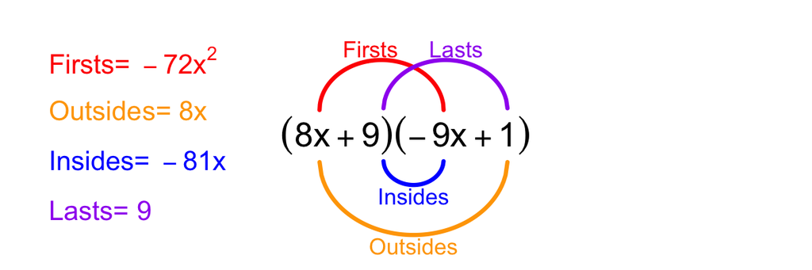

Either way, you should first get
$${-72}x^{2}+{8}x-{81}x+{9}$$

And, after combining like terms, you should get
$${-72}x^{2}-{73}x+{9}$$

Thus, $a=-72$ and $b=-73$ and $c=9$. This question specifically asked for the value of $b$, so the answer is $-73$.

Consider the following product of linear binomials:

$$({7}x+{9})(x-{8})$$

When the expression is expanded and like terms are combined, an equivalent expression can be expressed in standard form:

$$ax^2+bx+c$$

where $a$, $b$, and $c$ are integers.

- What is the value of $b$?

You could use the box method.

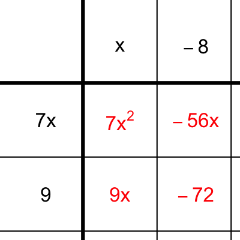

Or, you can FOIL...

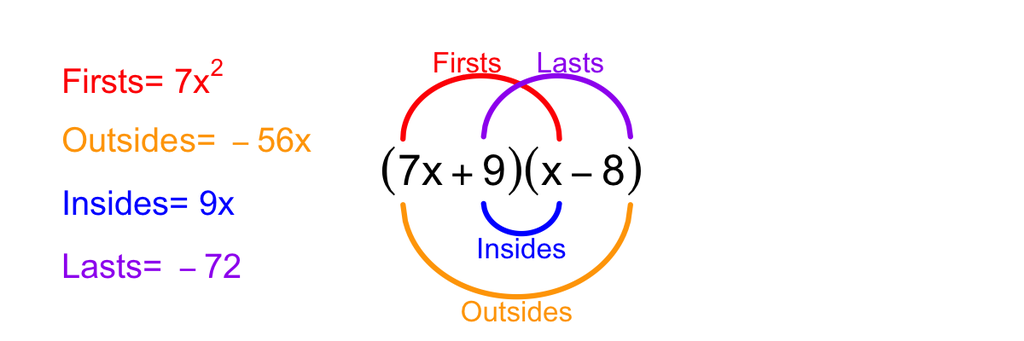

Either way, you should first get
$${7}x^{2}-{56}x+{9}x-{72}$$

And, after combining like terms, you should get
$${7}x^{2}-{47}x-{72}$$

Thus, $a=7$ and $b=-47$ and $c=-72$. This question specifically asked for the value of $b$, so the answer is $-47$.

Consider the following product of linear binomials:

$$({-5}x+{2})({9}x+{2})$$

When the expression is expanded and like terms are combined, an equivalent expression can be expressed in standard form:

$$ax^2+bx+c$$

where $a$, $b$, and $c$ are integers.

- What is the value of $b$?

You could use the box method.

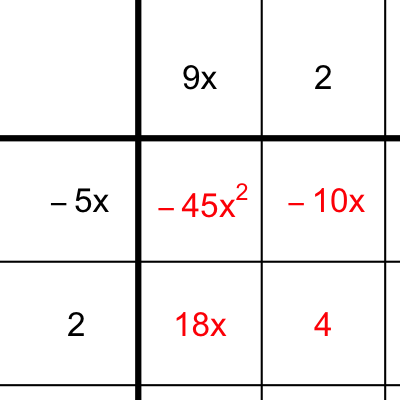

Or, you can FOIL...

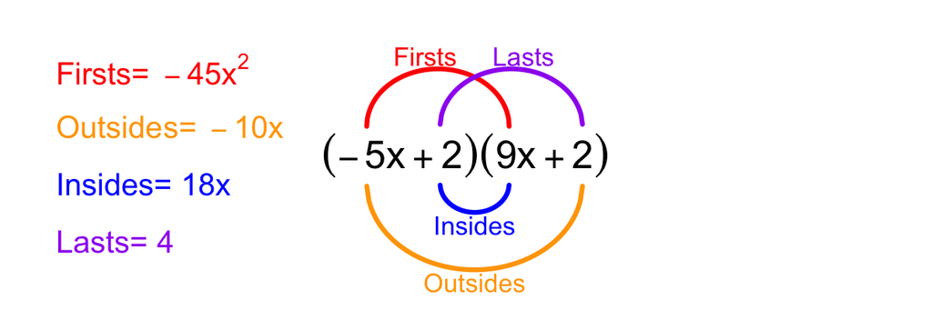

Either way, you should first get
$${-45}x^{2}-{10}x+{18}x+{4}$$

And, after combining like terms, you should get
$${-45}x^{2}+{8}x+{4}$$

Thus, $a=-45$ and $b=8$ and $c=4$. This question specifically asked for the value of $b$, so the answer is $8$.

Consider the following product of linear binomials:

$$({8}x+{9})(x-{8})$$

When the expression is expanded and like terms are combined, an equivalent expression can be expressed in standard form:

$$ax^2+bx+c$$

where $a$, $b$, and $c$ are integers.

- What is the value of $b$?

You could use the box method.

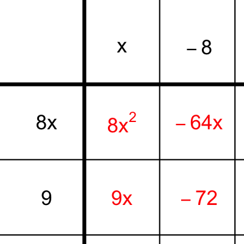

Or, you can FOIL...

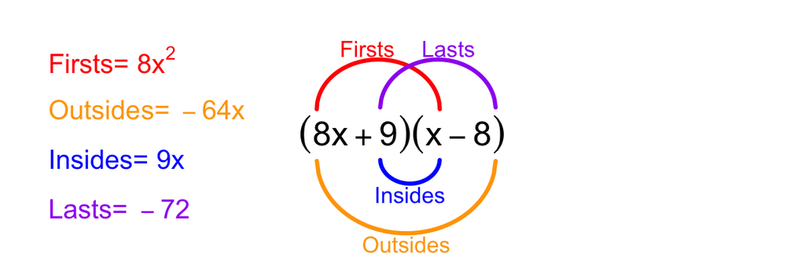

Either way, you should first get
$${8}x^{2}-{64}x+{9}x-{72}$$

And, after combining like terms, you should get
$${8}x^{2}-{55}x-{72}$$

Thus, $a=8$ and $b=-55$ and $c=-72$. This question specifically asked for the value of $b$, so the answer is $-55$.

Consider the following product of linear binomials:

$$({-9}x-{2})({6}x+{7})$$

When the expression is expanded and like terms are combined, an equivalent expression can be expressed in standard form:

$$ax^2+bx+c$$

where $a$, $b$, and $c$ are integers.

- What is the value of $b$?

You could use the box method.

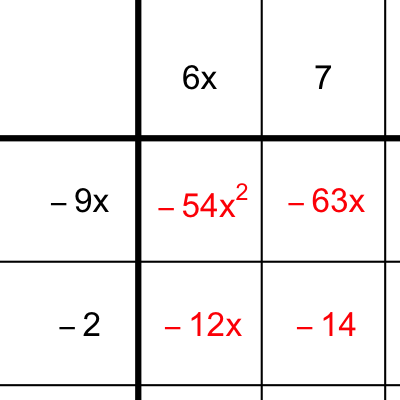

Or, you can FOIL...

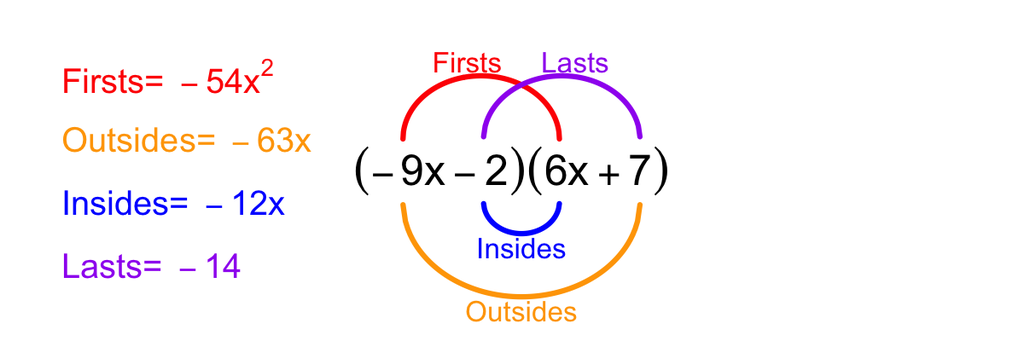

Either way, you should first get
$${-54}x^{2}-{63}x-{12}x-{14}$$

And, after combining like terms, you should get
$${-54}x^{2}-{75}x-{14}$$

Thus, $a=-54$ and $b=-75$ and $c=-14$. This question specifically asked for the value of $b$, so the answer is $-75$.

Consider the following product of linear binomials:

$$(-x-{6})({5}x-{7})$$

When the expression is expanded and like terms are combined, an equivalent expression can be expressed in standard form:

$$ax^2+bx+c$$

where $a$, $b$, and $c$ are integers.

- What is the value of $b$?

You could use the box method.

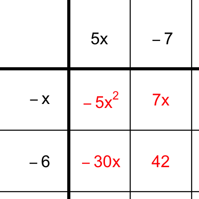

Or, you can FOIL...

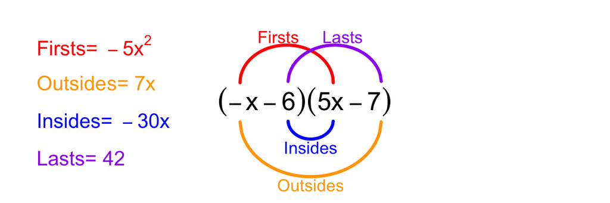

Either way, you should first get
$${-5}x^{2}+{7}x-{30}x+{42}$$

And, after combining like terms, you should get
$${-5}x^{2}-{23}x+{42}$$

Thus, $a=-5$ and $b=-23$ and $c=42$. This question specifically asked for the value of $b$, so the answer is $-23$.

The product of a linear polynomial times a quadratic polynomial is a cubic polynomial. Let $r(x)$ represent the product of the linear binomial and the quadratic trinomial shown below.

$$r(x)~~=~~\left({7}x+{6}\right) \cdot
\left({-2}x^{2}+{4}x+{7}\right)$$

The resulting cubic polynomial can be expressed in standard form.

$$r(x)~=~ax^3+bx^2+cx+d$$

Identify the coefficients $a$, $b$, $c$, and $d$.

- $a=$
- $b=$
- $c=$
- $d=$

| * | $7x$ | $6$ |
| --- | --- | --- |
| $-2x^2$ | $-14x^3$ | $-12x^2$ |
| $4x$ | $28x^2$ | $24x$ |
| $7$ | $49x$ | $42$ |

$$r(x)~~=~~
{-14}x^{3}+{28}x^{2}+{49}x-{12}x^{2}+{24}x+{42}$$

Combine like terms.

$$r(x)~~=~~
{-14}x^{3}+{16}x^{2}+{73}x+{42}$$

So,

- $a=-14$
- $b=16$
- $c=73$
- $d=42$

The product of a linear polynomial times a quadratic polynomial is a cubic polynomial. Let $r(x)$ represent the product of the linear binomial and the quadratic trinomial shown below.

$$r(x)~~=~~\left({-9}x+{3}\right) \cdot
\left({6}x^{2}+{7}x-{5}\right)$$

The resulting cubic polynomial can be expressed in standard form.

$$r(x)~=~ax^3+bx^2+cx+d$$

Identify the coefficients $a$, $b$, $c$, and $d$.

- $a=$
- $b=$
- $c=$
- $d=$

| * | $-9x$ | $3$ |
| --- | --- | --- |
| $6x^2$ | $-54x^3$ | $18x^2$ |
| $7x$ | $-63x^2$ | $21x$ |
| $-5$ | $45x$ | $-15$ |

$$r(x)~~=~~
{-54}x^{3}-{63}x^{2}+{45}x+{18}x^{2}+{21}x-{15}$$

Combine like terms.

$$r(x)~~=~~
{-54}x^{3}-{45}x^{2}+{66}x-{15}$$

So,

- $a=-54$
- $b=-45$
- $c=66$
- $d=-15$

The product of a linear polynomial times a quadratic polynomial is a cubic polynomial. Let $r(x)$ represent the product of the linear binomial and the quadratic trinomial shown below.

$$r(x)~~=~~\left({-4}x+{6}\right) \cdot
\left({5}x^{2}+x-{3}\right)$$

The resulting cubic polynomial can be expressed in standard form.

$$r(x)~=~ax^3+bx^2+cx+d$$

Identify the coefficients $a$, $b$, $c$, and $d$.

- $a=$
- $b=$
- $c=$
- $d=$

| * | $-4x$ | $6$ |
| --- | --- | --- |
| $5x^2$ | $-20x^3$ | $30x^2$ |
| $1x$ | $-4x^2$ | $6x$ |
| $-3$ | $12x$ | $-18$ |

$$r(x)~~=~~
{-20}x^{3}-{4}x^{2}+{12}x+{30}x^{2}+{6}x-{18}$$

Combine like terms.

$$r(x)~~=~~
{-20}x^{3}+{26}x^{2}+{18}x-{18}$$

So,

- $a=-20$
- $b=26$
- $c=18$
- $d=-18$

The product of a linear polynomial times a quadratic polynomial is a cubic polynomial. Let $r(x)$ represent the product of the linear binomial and the quadratic trinomial shown below.

$$r(x)~~=~~\left({7}x+{1}\right) \cdot
\left({9}x^{2}+{7}x+{8}\right)$$

The resulting cubic polynomial can be expressed in standard form.

$$r(x)~=~ax^3+bx^2+cx+d$$

Identify the coefficients $a$, $b$, $c$, and $d$.

- $a=$
- $b=$
- $c=$
- $d=$

| * | $7x$ | $1$ |
| --- | --- | --- |
| $9x^2$ | $63x^3$ | $9x^2$ |
| $7x$ | $49x^2$ | $7x$ |
| $8$ | $56x$ | $8$ |

$$r(x)~~=~~
{63}x^{3}+{49}x^{2}+{56}x+{9}x^{2}+{7}x+{8}$$

Combine like terms.

$$r(x)~~=~~
{63}x^{3}+{58}x^{2}+{63}x+{8}$$

So,

- $a=63$
- $b=58$
- $c=63$
- $d=8$

The product of a linear polynomial times a quadratic polynomial is a cubic polynomial. Let $r(x)$ represent the product of the linear binomial and the quadratic trinomial shown below.

$$r(x)~~=~~\left({-5}x-{2}\right) \cdot
\left(-x^{2}-{6}x-{7}\right)$$

The resulting cubic polynomial can be expressed in standard form.

$$r(x)~=~ax^3+bx^2+cx+d$$

Identify the coefficients $a$, $b$, $c$, and $d$.

- $a=$
- $b=$
- $c=$
- $d=$

| * | $-5x$ | $-2$ |
| --- | --- | --- |
| $-1x^2$ | $5x^3$ | $2x^2$ |
| $-6x$ | $30x^2$ | $12x$ |
| $-7$ | $35x$ | $14$ |

$$r(x)~~=~~
{5}x^{3}+{30}x^{2}+{35}x+{2}x^{2}+{12}x+{14}$$

Combine like terms.

$$r(x)~~=~~
{5}x^{3}+{32}x^{2}+{47}x+{14}$$

So,

- $a=5$
- $b=32$
- $c=47$
- $d=14$

The product of a linear polynomial times a quadratic polynomial is a cubic polynomial. Let $r(x)$ represent the product of the linear binomial and the quadratic trinomial shown below.

$$r(x)~~=~~\left(-x-{9}\right) \cdot
\left({2}x^{2}+{3}x+{8}\right)$$

The resulting cubic polynomial can be expressed in standard form.

$$r(x)~=~ax^3+bx^2+cx+d$$

Identify the coefficients $a$, $b$, $c$, and $d$.

- $a=$
- $b=$
- $c=$
- $d=$

| * | $-1x$ | $-9$ |
| --- | --- | --- |
| $2x^2$ | $-2x^3$ | $-18x^2$ |
| $3x$ | $-3x^2$ | $-27x$ |
| $8$ | $-8x$ | $-72$ |

$$r(x)~~=~~
{-2}x^{3}-{3}x^{2}-{8}x-{18}x^{2}-{27}x-{72}$$

Combine like terms.

$$r(x)~~=~~
{-2}x^{3}-{21}x^{2}-{35}x-{72}$$

So,

- $a=-2$
- $b=-21$
- $c=-35$
- $d=-72$